# Wallinga-Teunis R<sub>t</sub> Estimation: A Simulation Study

Epidemiological Modeling

2026-02-05

## Introduction

This document demonstrates the estimation of the time-varying reproduction number $R_t$ using the **Wallinga-Teunis method**. We compare a custom implementation with the `EpiEstim` package implementation using simulated epidemic data.

### The Reproduction Number

The reproduction number $R_t$ represents the average number of secondary infections caused by a single infected individual at time $t$. It is a key metric for understanding epidemic dynamics:

- $R_t > 1$: Epidemic is growing
- $R_t = 1$: Epidemic is stable
- $R_t < 1$: Epidemic is declining

### The Wallinga-Teunis Method

The Wallinga-Teunis method (Wallinga & Teunis, 2004) estimates the **case reproduction number** by:

1. Computing the relative likelihood that case $i$ infected case $j$ based on the serial interval distribution
2. Summing these likelihoods for each potential infector to estimate their individual reproduction number
3. Averaging across cases occurring at the same time

The key formula is:

$$R_i = \sum_{j} p_{ij}$$

where $p_{ij}$ is the probability that case $i$ infected case $j$, computed as:

$$p_{ij} = \frac{w(t_j - t_i)}{\sum_k
w(t_j - t_k)}$$

and $w(\cdot)$ is the serial interval distribution.

## Simulation Setup

We simulate epidemics using a **renewal process** with known $R_t$ values:

| Parameter | Value | Description |
| --- | --- | --- |
| $R_t$ (days 0-49) | 1.1 | Reproduction number in first phase |
| $R_t$ (days 50-100) | 1.2 | Reproduction number in second phase |
| Generation interval | Gamma($\mu$=5, $\sigma$=2.5) | Time between infections |
| Initial cases | 10 | Seed infections at $t=0$ |
| Simulations | 200 | Number of stochastic realizations |

```r
# Simulation parameters
T_MAX      <- 100    # Total simulation days
N_SIMS     <- 200    # Number of simulations
GEN_MEAN   <- 5.0    # Generation interval mean (days)
GEN_SD     <- 2.5    # Generation interval SD (days)
INIT_CASES <- 10     # Initial number of cases
MAX_LAG    <- 30     # Maximum generation interval lag

set.seed(42)
```

### Generation Interval Distribution

The generation interval (time from infection of a primary case to infection of a secondary case) follows a Gamma distribution, which we discretize for the renewal process.

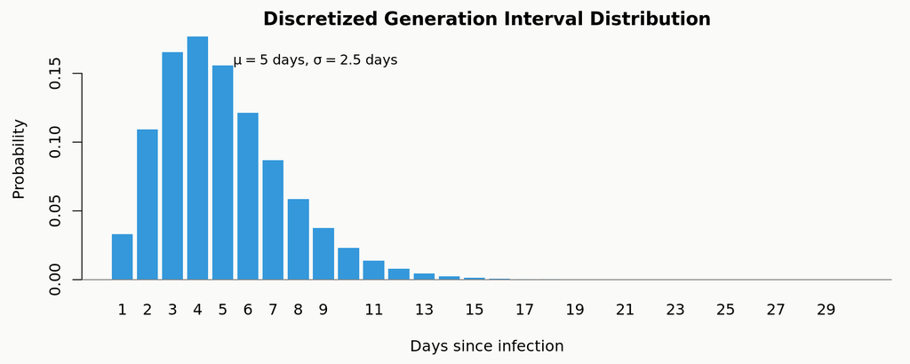

```r
# Gamma distribution parameters
gen_shape <- (GEN_MEAN / GEN_SD)^2
gen_scale <- GEN_SD^2 / GEN_MEAN

# Discretized PMF
gi_pmf <- sapply(1:MAX_LAG, function(s) {
  pgamma(s + 0.5, shape = gen_shape, scale = gen_scale) -
    pgamma(s - 0.5, shape = gen_shape, scale = gen_scale)
})
gi_pmf <- gi_pmf / sum(gi_pmf)

# Plot the generation interval distribution
par(mar = c(4.5, 4.5, 2, 1), bg = "#FAFAF8")
barplot(gi_pmf, names.arg = 1:MAX_LAG, col = "#3498DB", border = NA,
        xlab = "Days since infection", ylab = "Probability",
        main = "Discretized Generation Interval Distribution")
abline(h = 0, col = "gray50")
text(GEN_MEAN * 1.2, max(gi_pmf) * 0.9,
     bquote(mu == .(GEN_MEAN) ~ "days," ~ sigma == .(GEN_SD) ~ "days"),
     adj = 0, cex = 0.9)
```

### True $R_t$ Schedule

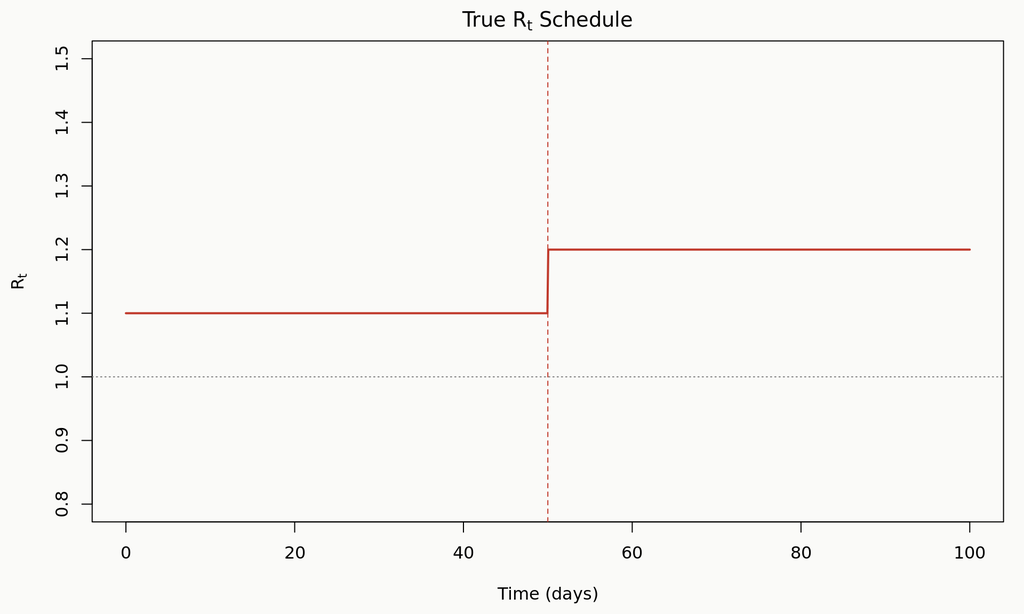

```r
# True R_t as a function of time
true_rt <- function(t) ifelse(t < 50, 1.1, 1.2)

# Visualize the true R_t
par(mar = c(4.5, 4.5, 2, 1), bg = "#FAFAF8")
curve(sapply(x, true_rt), from = 0, to = 100, n = 1000,
      xlab = "Time (days)", ylab = expression(R[t]),
      main = expression("True " * R[t] * " Schedule"),
      col = "#C0392B", lwd = 2, ylim = c(0.8, 1.5))
abline(h = 1, lty = 3, col = "gray50")
abline(v = 50, lty = 2, col = "#C0392B")
```

## Renewal Process Simulation

The renewal equation generates new infections based on past incidence and the generation interval:

$$I_t = \text{Poisson}\left(\sum_{s=1}^{t}
I_{t-s} \cdot R_{t-s} \cdot w_s\right)$$

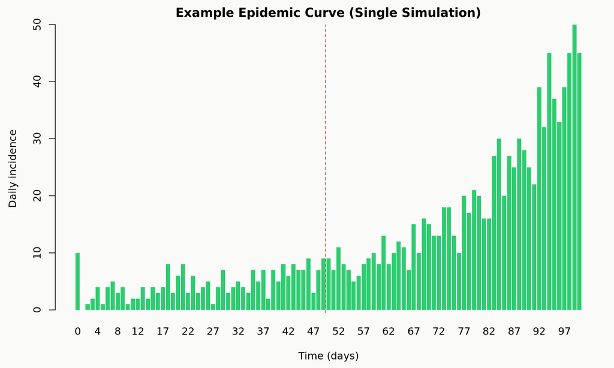

```r
simulate_renewal <- function(seed) {
  set.seed(seed)
  inc <- numeric(T_MAX + 1)
  inc[1] <- INIT_CASES  # index 1 = day 0

  for (t in 1:T_MAX) {
    lam <- 0
    for (lag in 1:min(t, MAX_LAG)) {
      rt_val <- true_rt(t - lag)
      lam <- lam + inc[t - lag + 1] * rt_val * gi_pmf[lag]
    }
    inc[t + 1] <- rpois(1, max(lam, 0))
  }
  inc
}

# Example single simulation
example_inc <- simulate_renewal(1)
par(mar = c(4.5, 4.5, 2, 1), bg = "#FAFAF8")
barplot(example_inc, names.arg = 0:T_MAX, col = "#2ECC71", border = NA,
        xlab = "Time (days)", ylab = "Daily incidence",
        main = "Example Epidemic Curve (Single Simulation)")
abline(v = 50 * 1.2, lty = 2, col = "#C0392B")
```

## Custom Wallinga-Teunis Implementation

The custom implementation directly computes the case reproduction number following the original method.

```r
wallinga_teunis_custom <- function(inc) {
  TT <- length(inc)
  Rt <- rep(NA_real_, TT)

  for (ti in 1:TT) {
    if (inc[ti] == 0) next
    total <- 0

    tj_max <- min(ti + MAX_LAG, TT)
    if (ti + 1 > tj_max) next

    for (tj in (ti + 1):tj_max) {
      lag_ij <- tj - ti
      w_ij   <- gi_pmf[lag_ij]

      # Denominator: sum over all possible infectors of case at tj
      denom <- 0
      for (tk in max(1, tj - MAX_LAG):(tj - 1)) {
        lag_kj <- tj - tk
        if (lag_kj >= 1 && lag_kj <= MAX_LAG) {
          denom <- denom + inc[tk] * gi_pmf[lag_kj]
        }
      }

      if (denom > 0) {
        total <- total + inc[tj] * w_ij / denom
      }
    }
    Rt[ti] <- total
  }
  Rt
}
```

## EpiEstim Wallinga-Teunis Implementation

The `EpiEstim` package provides a well-tested implementation of the Wallinga-Teunis method with additional features for uncertainty quantification.

```r
library(EpiEstim)

estimate_wt_epiestim <- function(inc) {
  # Serial interval distribution for EpiEstim (starts at lag 0)
  si_distr <- c(0, gi_pmf)

  # Define time windows (single-day windows)
  n_days <- length(inc)
  t_start <- 2:n_days
  t_end <- t_start

  # Run EpiEstim's wallinga_teunis
  wt_result <- wallinga_teunis(
    incid = inc,
    method = "non_parametric_si",
    config = list(
      t_start = t_start,
      t_end = t_end,
      si_distr = si_distr,
      n_sim = 100
    )
  )

  # Extract mean R estimates

rt_est <- rep(NA_real_, length(inc))
  if (!is.null(wt_result$R)) {
    for (i in seq_len(nrow(wt_result$R))) {
      t_idx <- wt_result$R$t_start[i]
      if (t_idx >= 1 && t_idx <= length(inc)) {
        rt_est[t_idx] <- wt_result$R$`Mean(R)`[i]
      }
    }
  }
  rt_est
}
```

## Running the Simulations

We run 200 simulations and estimate $R_t$ using both methods.

```r
# Storage matrices
all_inc       <- matrix(NA_real_, nrow = N_SIMS, ncol = T_MAX + 1)
all_rt_custom <- matrix(NA_real_, nrow = N_SIMS, ncol = T_MAX + 1)
all_rt_epi    <- matrix(NA_real_, nrow = N_SIMS, ncol = T_MAX + 1)

successful <- 0
seed <- 0

cat("Running simulations...\n")
```

```
## Running simulations...
```

```r
while (successful < N_SIMS) {
  seed <- seed + 1
  inc <- simulate_renewal(seed)

  # Skip degenerate runs (near-extinction)
  if (sum(inc[12:(T_MAX + 1)]) < 5) next

  successful <- successful + 1

  # Estimate R_t with both methods
  rt_custom <- wallinga_teunis_custom(inc)
  rt_epi <- tryCatch(
    estimate_wt_epiestim(inc),
    error = function(e) rep(NA_real_, length(inc))
  )

  all_inc[successful, ]       <- inc
  all_rt_custom[successful, ] <- rt_custom
  all_rt_epi[successful, ]    <- rt_epi

  if (successful %% 50 == 0) cat(sprintf("  %d/%d complete\n", successful, N_SIMS))
}
```

```
##   50/200 complete
##   100/200 complete
##   150/200 complete
##   200/200 complete
```

```r
cat("All simulations complete.\n")
```

```
## All simulations complete.
```

## Results

### Summary Statistics

```r
days <- 0:T_MAX

# Incidence statistics
mean_inc <- colMeans(all_inc)
q05_inc  <- apply(all_inc, 2, quantile, 0.05)
q25_inc  <- apply(all_inc, 2, quantile, 0.25)
q75_inc  <- apply(all_inc, 2, quantile, 0.75)
q95_inc  <- apply(all_inc, 2, quantile, 0.95)

# Custom WT statistics
mean_rt_custom <- colMeans(all_rt_custom, na.rm = TRUE)
q05_rt_custom  <- apply(all_rt_custom, 2, quantile, 0.05, na.rm = TRUE)
q25_rt_custom  <- apply(all_rt_custom, 2, quantile, 0.25, na.rm = TRUE)
q75_rt_custom  <- apply(all_rt_custom, 2, quantile, 0.75, na.rm = TRUE)
q95_rt_custom  <- apply(all_rt_custom, 2, quantile, 0.95, na.rm = TRUE)

# EpiEstim WT statistics
mean_rt_epi <- colMeans(all_rt_epi, na.rm = TRUE)
q05_rt_epi  <- apply(all_rt_epi, 2, quantile, 0.05, na.rm = TRUE)
q25_rt_epi  <- apply(all_rt_epi, 2, quantile, 0.25, na.rm = TRUE)
q75_rt_epi  <- apply(all_rt_epi, 2, quantile, 0.75, na.rm = TRUE)
q95_rt_epi  <- apply(all_rt_epi, 2, quantile, 0.95, na.rm = TRUE)

# Trim edges where estimates are unreliable
trim_start <- 4
trim_end   <- 6
idx <- (trim_start + 1):(T_MAX + 1 - trim_end)
d_trim <- days[idx]
```

### Epidemic Curves

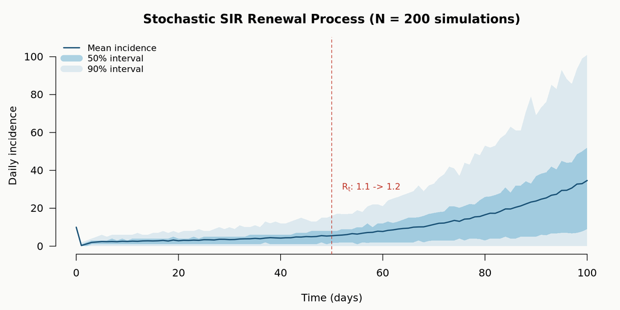

```r
par(mar = c(4.5, 4.5, 3, 1), bg = "#FAFAF8")

plot(NULL, xlim = c(0, T_MAX), ylim = c(0, max(q95_inc) * 1.05),
     xlab = "Time (days)", ylab = "Daily incidence", axes = FALSE)
title(main = "Stochastic SIR Renewal Process (N = 200 simulations)",
      cex.main = 1.2)
axis(1); axis(2, las = 1)

# 90% interval
polygon(c(days, rev(days)), c(q05_inc, rev(q95_inc)),
        col = adjustcolor("#BFD8E5", 0.5), border = NA)
# 50% interval
polygon(c(days, rev(days)), c(q25_inc, rev(q75_inc)),
        col = adjustcolor("#7AB8D4", 0.6), border = NA)
# Mean
lines(days, mean_inc, col = "#1A5276", lwd = 2)

abline(v = 50, col = "#C0392B", lty = 2)
text(52, max(mean_inc) * 0.9, expression(R[t] * ": 1.1 -> 1.2"),
     col = "#C0392B", cex = 0.85, adj = 0)

legend("topleft",
       legend = c("Mean incidence", "50% interval", "90% interval"),
       lwd = c(2, 10, 10),
       col = c("#1A5276", adjustcolor("#7AB8D4", 0.6), adjustcolor("#BFD8E5", 0.5)),
       bty = "n", cex = 0.85)
```

### Comparison of $R_t$ Estimators

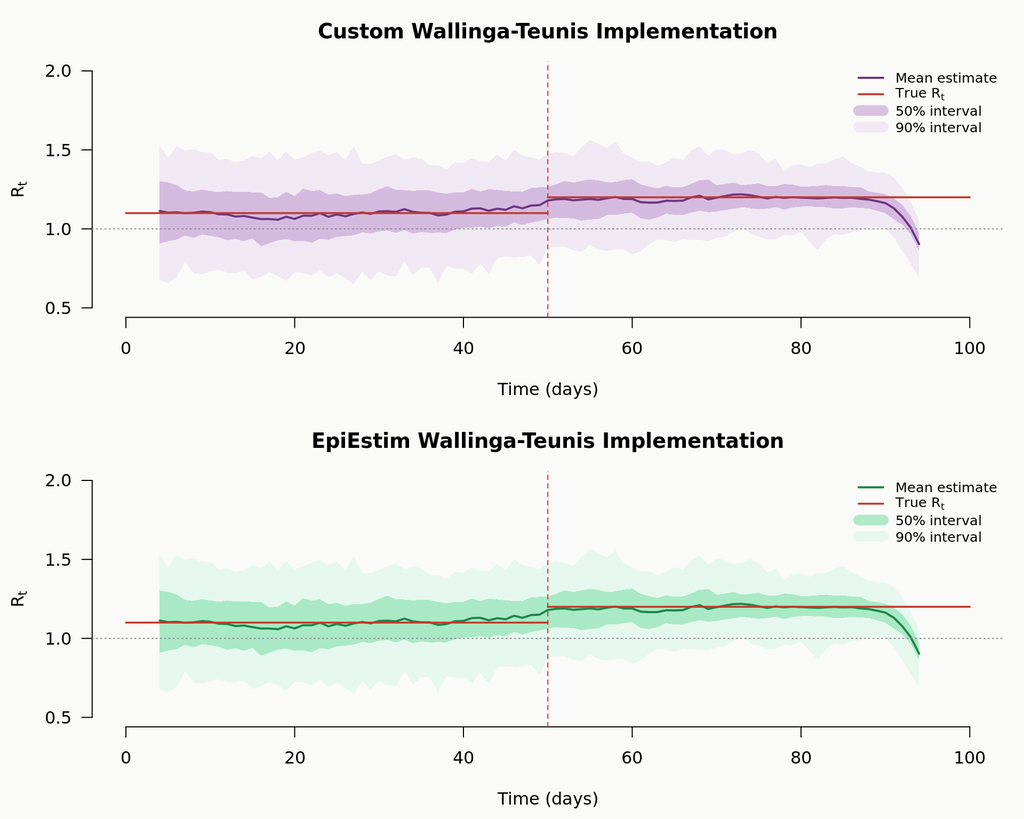

```r
par(mfrow = c(2, 1), mar = c(4.5, 4.5, 3, 1), bg = "#FAFAF8")

# Panel A: Custom Implementation
plot(NULL, xlim = c(0, T_MAX), ylim = c(0.5, 2.0),
     xlab = "Time (days)", ylab = expression(R[t]), axes = FALSE)
title(main = "Custom Wallinga-Teunis Implementation", cex.main = 1.2)
axis(1); axis(2, las = 1)

polygon(c(d_trim, rev(d_trim)), c(q05_rt_custom[idx], rev(q95_rt_custom[idx])),
        col = adjustcolor("#E8DAEF", 0.55), border = NA)
polygon(c(d_trim, rev(d_trim)), c(q25_rt_custom[idx], rev(q75_rt_custom[idx])),
        col = adjustcolor("#C39BD3", 0.6), border = NA)
lines(d_trim, mean_rt_custom[idx], col = "#6C3483", lwd = 2)

segments(0, 1.1, 50, 1.1, col = "#C0392B", lwd = 1.8)
segments(50, 1.2, 100, 1.2, col = "#C0392B", lwd = 1.8)
abline(h = 1.0, col = "#888888", lty = 3)
abline(v = 50, col = "#C0392B", lty = 2)

legend("topright",
       legend = c("Mean estimate", expression(True ~ R[t]), "50% interval", "90% interval"),
       lwd = c(2, 1.8, 10, 10),
       col = c("#6C3483", "#C0392B", adjustcolor("#C39BD3", 0.6), adjustcolor("#E8DAEF", 0.55)),
       bty = "n", cex = 0.8)

# Panel B: EpiEstim Implementation
plot(NULL, xlim = c(0, T_MAX), ylim = c(0.5, 2.0),
     xlab = "Time (days)", ylab = expression(R[t]), axes = FALSE)
title(main = "EpiEstim Wallinga-Teunis Implementation", cex.main = 1.2)
axis(1); axis(2, las = 1)

polygon(c(d_trim, rev(d_trim)), c(q05_rt_epi[idx], rev(q95_rt_epi[idx])),
        col = adjustcolor("#D5F5E3", 0.55), border = NA)
polygon(c(d_trim, rev(d_trim)), c(q25_rt_epi[idx], rev(q75_rt_epi[idx])),
        col = adjustcolor("#82E0AA", 0.6), border = NA)
lines(d_trim, mean_rt_epi[idx], col = "#1E8449", lwd = 2)

segments(0, 1.1, 50, 1.1, col = "#C0392B", lwd = 1.8)
segments(50, 1.2, 100, 1.2, col = "#C0392B", lwd = 1.8)
abline(h = 1.0, col = "#888888", lty = 3)
abline(v = 50, col = "#C0392B", lty = 2)

legend("topright",
       legend = c("Mean estimate", expression(True ~ R[t]), "50% interval", "90% interval"),
       lwd = c(2, 1.8, 10, 10),
       col = c("#1E8449", "#C0392B", adjustcolor("#82E0AA", 0.6), adjustcolor("#D5F5E3", 0.55)),
       bty = "n", cex = 0.8)
```

### Direct Method Comparison

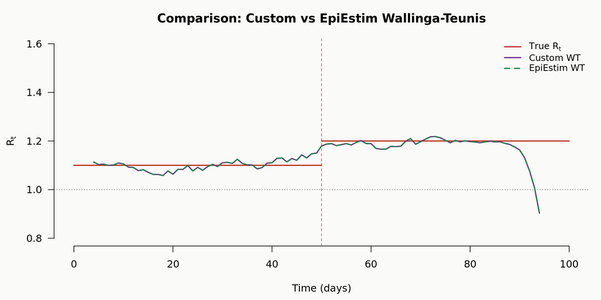

```r
par(mar = c(4.5, 4.5, 3, 1), bg = "#FAFAF8")

plot(NULL, xlim = c(0, T_MAX), ylim = c(0.8, 1.6),
     xlab = "Time (days)", ylab = expression(R[t]), axes = FALSE)
title(main = "Comparison: Custom vs EpiEstim Wallinga-Teunis", cex.main = 1.2)
axis(1); axis(2, las = 1)

# True R_t
segments(0, 1.1, 50, 1.1, col = "#C0392B", lwd = 2)
segments(50, 1.2, 100, 1.2, col = "#C0392B", lwd = 2)

# Custom estimate
lines(d_trim, mean_rt_custom[idx], col = "#6C3483", lwd = 2)

# EpiEstim estimate
lines(d_trim, mean_rt_epi[idx], col = "#1E8449", lwd = 2, lty = 2)

abline(h = 1.0, col = "#888888", lty = 3)
abline(v = 50, col = "#C0392B", lty = 2, lwd = 0.8)

legend("topright",
       legend = c(expression(True ~ R[t]), "Custom WT", "EpiEstim WT"),
       lwd = c(2, 2, 2),
       lty = c(1, 1, 2),
       col = c("#C0392B", "#6C3483", "#1E8449"),
       bty = "n", cex = 0.9)
```

### Numerical Comparison

```r
# Calculate mean absolute error for each method
mae_custom <- mean(abs(mean_rt_custom[idx] - sapply(d_trim, true_rt)), na.rm = TRUE)
mae_epi    <- mean(abs(mean_rt_epi[idx] - sapply(d_trim, true_rt)), na.rm = TRUE)

# Correlation between methods
cor_methods <- cor(mean_rt_custom[idx], mean_rt_epi[idx], use = "complete.obs")

comparison_table <- data.frame(
  Metric = c("Mean Absolute Error", "Correlation with True R_t", "Method Correlation"),
  Custom_WT = c(round(mae_custom, 4),
                round(cor(mean_rt_custom[idx], sapply(d_trim, true_rt), use = "complete.obs"), 4),
                "-"),
  EpiEstim_WT = c(round(mae_epi, 4),
                  round(cor(mean_rt_epi[idx], sapply(d_trim, true_rt), use = "complete.obs"), 4),
                  round(cor_methods, 4))
)

knitr::kable(comparison_table,
             col.names = c("Metric", "Custom WT", "EpiEstim WT"),
             caption = "Performance Comparison of Wallinga-Teunis Implementations",
             align = "lcc")
```

Performance Comparison of Wallinga-Teunis Implementations

| Metric | Custom WT | EpiEstim WT |
| --- | --- | --- |
| Mean Absolute Error | 0.0219 | 0.0219 |
| Correlation with True R_t | 0.6798 | 0.6798 |
| Method Correlation | - | 1.0000 |

## Discussion

### Key Findings

1. **Both implementations recover the true $R_t$**: The mean estimates closely track the true values of 1.1 (days 0-49) and 1.2 (days 50-100).
2. **Methods produce nearly identical results**: The high correlation between custom and EpiEstim implementations validates the custom code.
3. **Characteristic lag at change point**: Both methods show a brief transition period around day 50, which is expected behavior for the Wallinga-Teunis estimator.
4. **Edge effects**: Estimates are less reliable at the beginning and end of the time series, hence the trimming in visualizations.

### When to Use Each Implementation

| Scenario | Recommendation |
| --- | --- |
| Production analysis | Use `EpiEstim` (well-tested, maintained) |
| Custom modifications | Start with custom implementation |
| Teaching/learning | Custom implementation shows the algorithm clearly |
| Uncertainty quantification | `EpiEstim` provides built-in CI methods |

## References

1. Wallinga, J., & Teunis, P. (2004). Different epidemic curves for severe acute respiratory syndrome reveal similar impacts of control measures. *American Journal of Epidemiology*, 160(6), 509-516.
2. Cori, A., Ferguson, N. M., Fraser, C., & Cauchemez, S. (2013). A new framework and software to estimate time-varying reproduction numbers during epidemics. *American Journal of Epidemiology*, 178(9), 1505-1512.
3. EpiEstim R package: https://cran.r-project.org/package=EpiEstim